# Seward Park Hemlock Study

2024-03-04

### Western Hemlock mortality reported throughout the Puget lowlands since at least 2015.

Researchers initially believed that this unusual mortality was caused by *Rhizoctonia butini*, a fungus in the order Cantharellales. This mechanism has since lost favor (personal communication, Jared LeBoldus, OSU Corvallis, personal communication), but no replacement theory has arisen.

Scientists and citizens commonly suggest that the mortality is due simply to old age - normal senescence - due to changes in weather patterns due to climate change.

We suggest that neither hypothesis fits our data, and that the search for the causes of hemlock decline should continue.

Seward Park’s remnant old-growth urban forest, 120 acres on a peninsula in Lake Washington, offers the opportunity to study this problem. This forest has in the neighborhood of 800 Western Hemlock trees, of all ages, from newborn seedlings to four foot diameter 250 year old giants.

Informal observation led forest steward Paul Shannon to suppose that Two small (hectare-sized) hemlock-rich sites at Seward have roughly equivalent age and density distributions, yet radically different health profiles. These contrasting sites offer the opportunity to study contrasting health and disease, and perhaps to identify the mechanism of the regional hemlock decline, where confounding factors are eliminated: age distributions are similar, weather patterns are identical, mortality is radically diffeent.

### “Graveyard” and “Garden”

These two dense hemlock sites, initially identified by informal inspection, have comparable age distribution - estimated from tree diameter - and contasting health.

Subsequent mapping and analysis refined these results - see below.

[figure not shown]

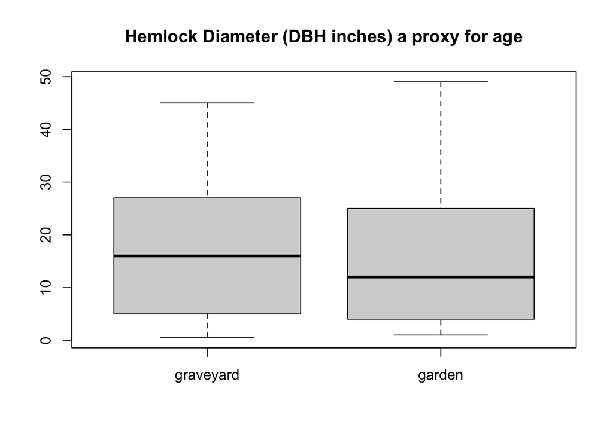

### Students Mapped, Measured and Assessed 600 Hemlock Trees

Between January and March, two Univeristy of Washington students from the Program on the Environment, in their senior Capstone Research Project, along with a Garfield High School junior, spent about 200 hours in the forest, collecting data to test the hypothesis that

1. dense hemlock stands
2. of similar age distrituion
3. exposed to essentially identical weather patterns
4. nonethess exhibed sharply contrasting health
5. thereby complicating popular notions that hemlock decline is due to
   - normal senescence
   - changing weather patterns associated with climate change

Here is a screenshot of the resulting [interactive map](https://pshannon.net/hemlockSurvey2024). The blue circles are hand-drawn visual estimates of the boundaries of the two informally identified contrasting sites. These are replace below by analytically derived boundaries.

[figure not shown]

### Density Maps: All Hemlocks, dying and dead, health hemlocks

Kernel Density solves the “overplotting” problem seen in the map above, in which the regional state of the forest is obscured by the large number of individulally measures trees. The leftmost plot shows the density of all hemlocks. The middle shows the density of dead and low health trees. The rightmost plot shows the distribution of healthy hemlocks.

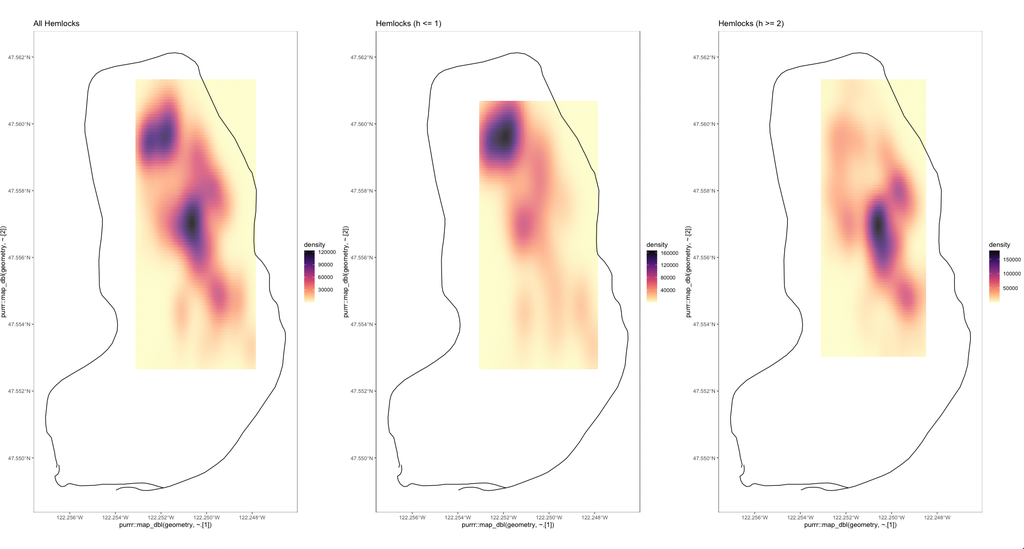

### Selecting Contrasting Candidate Sites for Further Study

Out next step is to define two sites of

1. similar size
2. similar density of hemlocks
3. contrasting health status

Our method:

1. subset the full observation table by latitude and longitude
2. poor health: trees northwest of 47.558711, -122.250358
3. good health: trees south and east of that point
4. calculate kernel densities of hemlocks in both regions
5. from these densities, identify the boundaries of comparable sites

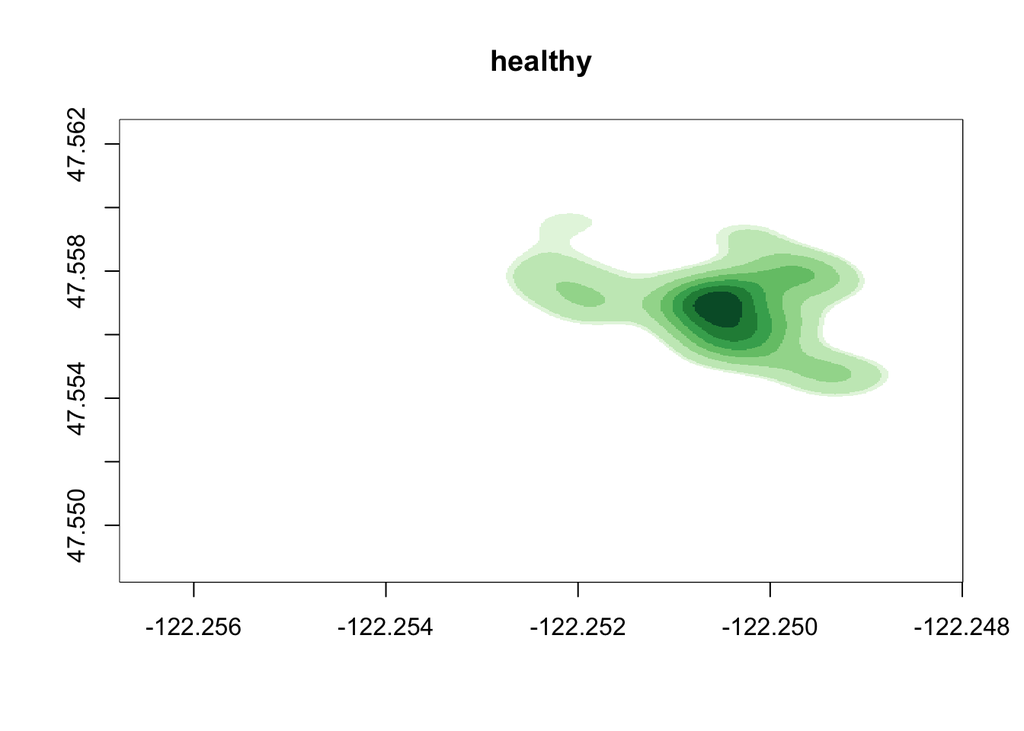

```r
library(MASS)
library(RColorBrewer)
options(digits=12)


f <- "https://pshannon.net/hemlockSurvey2024/tblFinal.csv"
tbl <- read.table(f, sep=",", header=TRUE, as.is=TRUE, nrow=-1, quote="")
     # get just the healthy trees
tbl.x <- subset(tbl, h>=2)
min.density <- 30000
cellCount <- 500
osm.limits <- c(-122.25676, -122.248006, 47.548233, 47.562744) # open street map
limits <- osm.limits

f.healthy <- kde2d(tbl.x$lon, tbl.x$lat, n=cellCount, lims=limits)
z <- f.healthy$z
     # zero out low density cells
z[z <min.density] <- 0
f.healthy$z <- z
     # display if you wish

healthy.colors <- brewer.pal(8, "Greens")
healthy.colors[1] <- "#FFFFFF"
sick.colors <- brewer.pal(8, "Reds")
sick.colors[1] <- "#FFFFFF"

image(f.healthy, main="healthy", col=healthy.colors) #, zlim = c(0, 0.05))
```

```r
      # can we get the boundary of the highest density region
      # from the contour?

tbl.x <- subset(tbl, h<=1)
f.sick <- kde2d(tbl.x$lon, tbl.x$lat, n=cellCount, lims=limits)
z <- f.sick$z
z[z <min.density] <- NA
f.sick$z <- z
range(f.sick$z)
```

```
## [1] NA NA
```

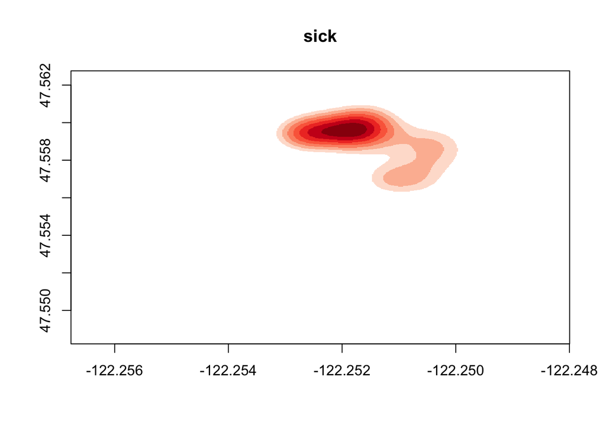

```r
#pdf("sick.pdf")
image(f.sick, main="sick", add=FALSE, col=sick.colors)
```

```r
boundaries.sick <- contourLines(f.sick)
boundaries.healthy <- contourLines(f.healthy)
print(as.numeric(unlist(lapply(boundaries.sick, "[", "level"))))
```

```
##  [1]  40000  50000  60000  60000  70000  80000  90000 100000 110000 120000 130000
```

```r
print(length(boundaries.sick[[10]]$x))
```

```
## [1] 139
```

```r
print(as.numeric(unlist(lapply(boundaries.healthy, "[", "level"))))
```

```
##  [1]  10000  20000  30000  40000  50000  50000  60000  70000  80000  90000 100000 110000 120000
## [14] 130000
```

```r
print(length(boundaries.healthy[[11]]$x))
```

```
## [1] 223
```

```r
# x <- boundaries.sick[[6]]$x
# y <- boundaries.sick[[6]]$y
# for(i in seq_len(length(x))){
#   print(sprintf("{lat: %12.8f, lng: %12.8f},", y[i], x[i]))
#   }

# x <- boundaries.healthy[[6]]$x
# y <- boundaries.healthy[[6]]$y
# for(i in seq_len(length(x))){
#   print(sprintf("{lat: %12.8f, lng: %12.8f},", y[i], x[i]))
#   }
```

### New Density-derived Boundaries for Hemlock Graveyard and Garden

[figure not shown]